# GA4 sample ecommerce performance dashboard

Sessions

360,089

Engaged sessions

228,303

Engagement rate

63.4%

Sessions and engaged sessions per day (sample data)

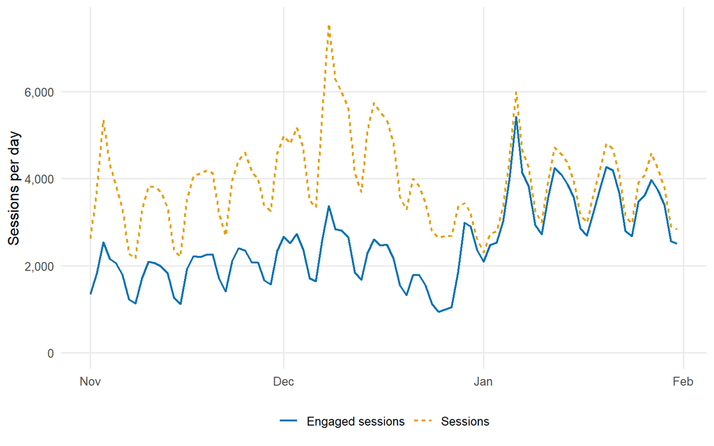

Engagement rate per day (sample data)

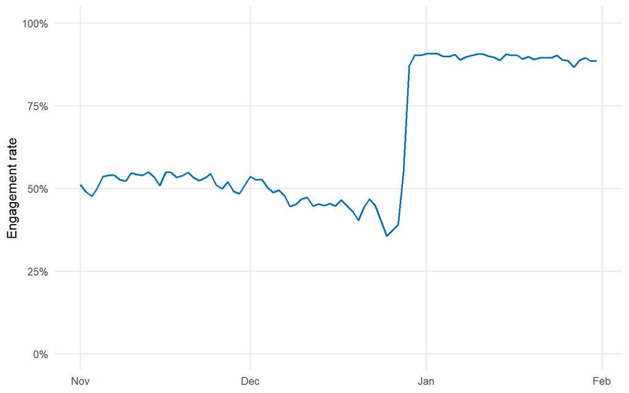

**KPI definitions.** *Sessions*: distinct user_pseudo_id + ga_session_id. *Engaged sessions*: sessions with 10 or more seconds of engagement, a purchase, or 2 or more page views (GA4 rule, rebuilt from events). *Engagement rate*: engaged sessions divided by sessions.

**Limitations.** Sample data from a different organisation’s ecommerce site; patterns do not describe CMRD users. The engaged-session rule is rebuilt from events and has not been compared with GA4’s own flag. Obfuscation and null values may affect counts.

New and returning users, share of daily active users by month (sample data)

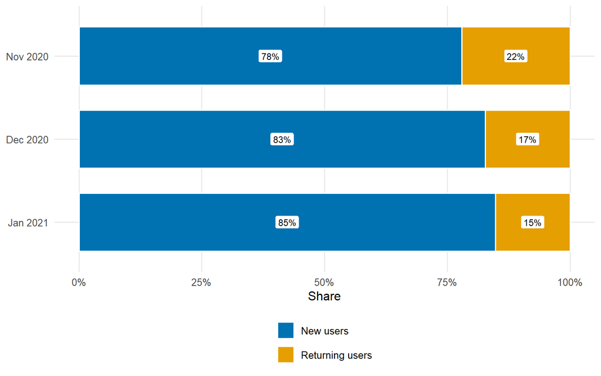

Channel mix, share of sessions by month (sample data)

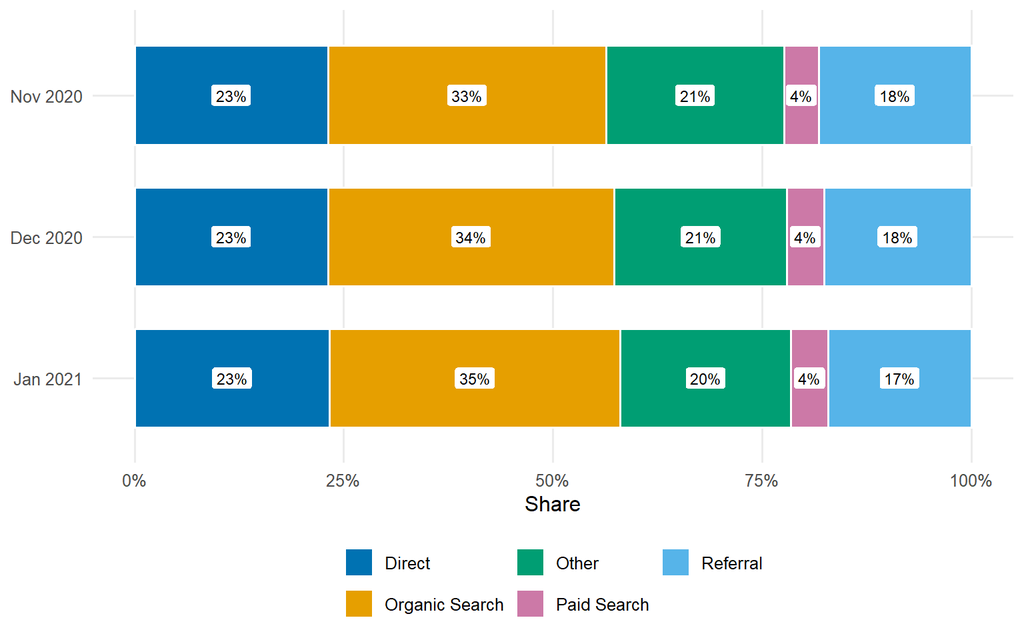

Device split, share of sessions by month (sample data)

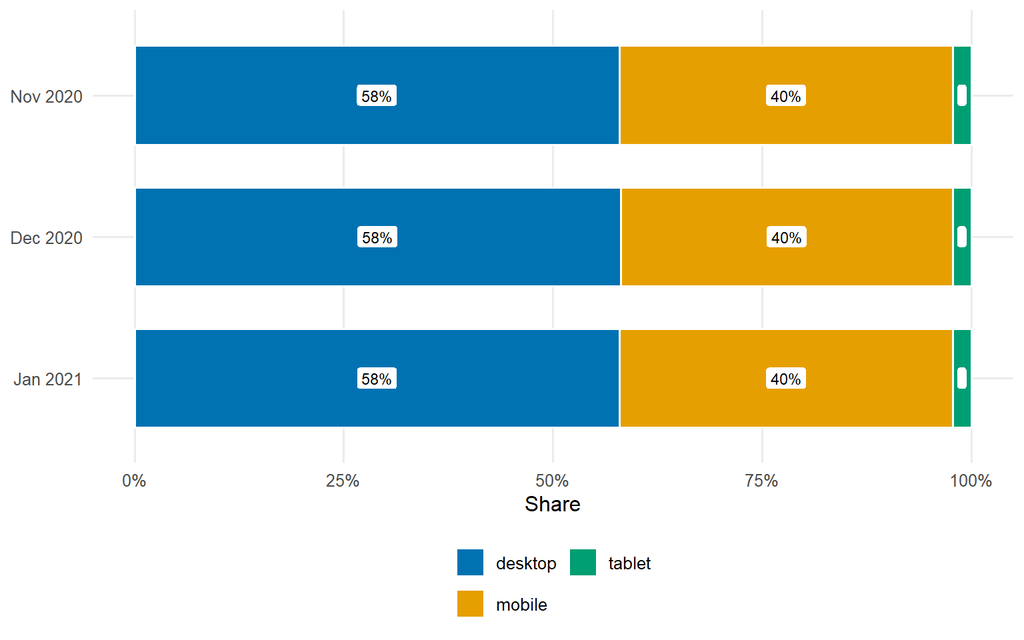

**KPI definitions.** *New users*: users with a session numbered 1 on that day. *Returning users*: active users that day who are not new. Both are daily distinct counts, so shares here are of user-days (daily active users summed over the month), not of distinct users. *Channel mix*: share of sessions by channel, grouped from traffic_source medium. *Device split*: share of sessions by device category.

**Limitations.** Channel comes from user first-touch traffic_source in this dataset, not the session’s own source, and “Other” collects every medium not listed. Sample data from a different organisation; not CMRD users.

Funnel window: 25 Nov 2020 to 31 Jan 2021. Earlier days are excluded because the raw sample has no or partial add_to_cart events on 1 to 24 Nov 2020.

Sessions reaching each funnel step (sample data)

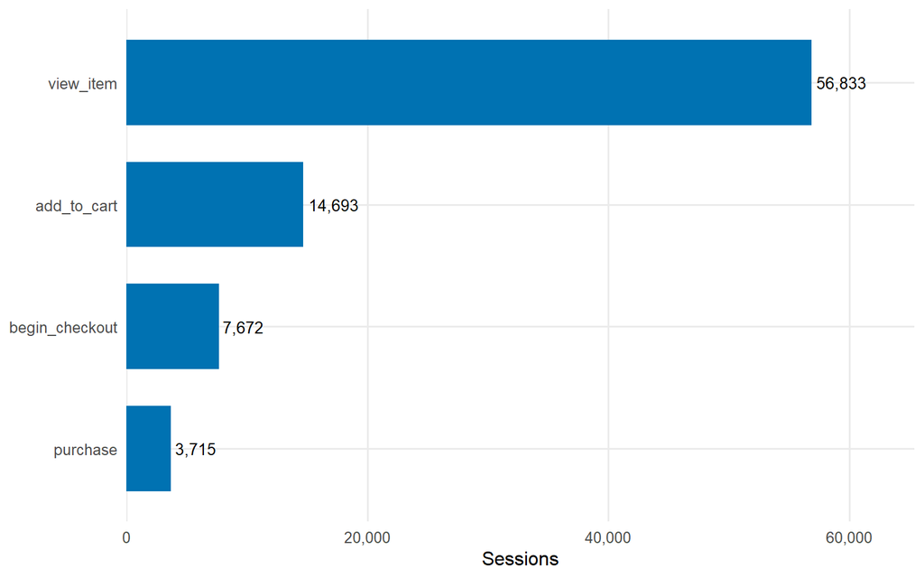

Step drop-off (sample data)

| Step | Sessions | Drop-off from previous step |
| --- | --- | --- |
| view_item | 56,833 | n/a |
| add_to_cart | 14,693 | 74.1% |
| begin_checkout | 7,672 | 47.8% |
| purchase | 3,715 | 51.6% |

**KPI definitions.** *Funnel sessions*: sessions with at least one event of that step; order within a session is not checked. *Step drop-off*: 1 minus (sessions at step divided by sessions at the previous step).

**Limitations.** Not a strict sequence, so drop-off is indicative. Totals cover only the funnel window above. Sample data from a different organisation; not CMRD users.